# Alternative Explorations of the Online Retail Dataset

# 1 Load Data

We first want to load our datasets and prepare them for some simple association rules mining.

```r
tnx_data_tbl <- read_rds("data/retail_data_cleaned_tbl.rds")

tnx_data_tbl %>% glimpse()
```

```
## Rows: 1,044,848
## Columns: 23
## $ row_id            <chr> "ROW0000001", "ROW0000002", "ROW0000003", "ROW000000…
## $ excel_sheet       <chr> "Year 2009-2010", "Year 2009-2010", "Year 2009-2010"…
## $ invoice_id        <chr> "489434", "489434", "489434", "489434", "489434", "4…
## $ stock_code        <chr> "85048", "79323P", "79323W", "22041", "21232", "2206…
## $ description       <chr> "15CM CHRISTMAS GLASS BALL 20 LIGHTS", "PINK CHERRY …
## $ quantity          <dbl> 12, 12, 12, 48, 24, 24, 24, 10, 12, 12, 24, 12, 10, …
## $ invoice_date      <date> 2009-12-01, 2009-12-01, 2009-12-01, 2009-12-01, 200…
## $ price             <dbl> 6.95, 6.75, 6.75, 2.10, 1.25, 1.65, 1.25, 5.95, 2.55…
## $ customer_id       <chr> "13085", "13085", "13085", "13085", "13085", "13085"…
## $ country           <chr> "United Kingdom", "United Kingdom", "United Kingdom"…
## $ stock_code_upr    <chr> "85048", "79323P", "79323W", "22041", "21232", "2206…
## $ cancellation      <lgl> FALSE, FALSE, FALSE, FALSE, FALSE, FALSE, FALSE, FAL…
## $ invoice_dttm      <dttm> 2009-12-01 07:45:00, 2009-12-01 07:45:00, 2009-12-0…
## $ invoice_month     <fct> December, December, December, December, December, De…
## $ invoice_dow       <fct> Tuesday, Tuesday, Tuesday, Tuesday, Tuesday, Tuesday…
## $ invoice_dom       <chr> "01", "01", "01", "01", "01", "01", "01", "01", "01"…
## $ invoice_hour      <chr> "07", "07", "07", "07", "07", "07", "07", "07", "07"…
## $ invoice_minute    <chr> "45", "45", "45", "45", "45", "45", "45", "45", "45"…
## $ invoice_woy       <chr> "49", "49", "49", "49", "49", "49", "49", "49", "49"…
## $ invoice_ym        <chr> "200912", "200912", "200912", "200912", "200912", "2…
## $ stock_value       <dbl> 83.40, 81.00, 81.00, 100.80, 30.00, 39.60, 30.00, 59…
## $ invoice_monthprop <dbl> 0.04347826, 0.04347826, 0.04347826, 0.04347826, 0.04…
## $ exclude           <lgl> FALSE, FALSE, FALSE, FALSE, FALSE, FALSE, FALSE, FAL…
```

To use our rules mining we just need the invoice data and the stock code, so we can ignore the rest. Also, we ignore the issue of returns and just look at purchases.

```r
tnx_purchase_tbl <- tnx_data_tbl %>%
  filter(
    quantity > 0,
    price > 0,
    exclude == FALSE
    ) %>%
  drop_na(customer_id) %>%
  mutate(stock_code = str_to_upper(stock_code)) %>%
  select(
    invoice_id, stock_code, customer_id, quantity, price, stock_value,
    description
    )

tnx_purchase_tbl %>% glimpse()
```

```
## Rows: 788,206
## Columns: 7
## $ invoice_id  <chr> "489434", "489434", "489434", "489434", "489434", "489434"…
## $ stock_code  <chr> "85048", "79323P", "79323W", "22041", "21232", "22064", "2…
## $ customer_id <chr> "13085", "13085", "13085", "13085", "13085", "13085", "130…
## $ quantity    <dbl> 12, 12, 12, 48, 24, 24, 24, 10, 12, 12, 24, 12, 10, 18, 3,…
## $ price       <dbl> 6.95, 6.75, 6.75, 2.10, 1.25, 1.65, 1.25, 5.95, 2.55, 3.75…
## $ stock_value <dbl> 83.40, 81.00, 81.00, 100.80, 30.00, 39.60, 30.00, 59.50, 3…
## $ description <chr> "15CM CHRISTMAS GLASS BALL 20 LIGHTS", "PINK CHERRY LIGHTS…
```

We also load the stock description data, as this will be useful as part of the graph analysis.

```r
stock_description_tbl <- read_rds("data/stock_description_tbl.rds")

stock_description_tbl %>% glimpse()
```

```
## Rows: 4,725
## Columns: 2
## $ stock_code <chr> "10002", "10002R", "10080", "10109", "10120", "10123C", "10…
## $ desc       <chr> "INFLATABLE POLITICAL GLOBE", "ROBOT PENCIL SHARPNER", "GRO…
```

# 2 Basket Analysis

We want to do some basic basket analysis before we investigate using full ‘association rules’ libraries for our modelling.

Rather than repeating all the logic, it might be worth looking at building some basic code to construct all the item pairs in each basket.

```r
construct_pairwise_items <- function(stock_codes) {
  pairs_tbl <- expand_grid(
      one = stock_codes,
      two = stock_codes
      ) %>%
    filter(one < two)

  return(pairs_tbl)
}

basket_data_tbl <- tnx_purchase_tbl %>%
  group_by(invoice_id) %>%
  summarise(
    .groups = "drop",

    stock_codes = list(stock_code)
    ) %>%
  mutate(
    basket_data = future_map(
      stock_codes, construct_pairwise_items,
      .progress = TRUE
      )
    )

basket_data_tbl %>% glimpse()
```

```
## Rows: 36,594
## Columns: 3
## $ invoice_id  <chr> "489434", "489435", "489436", "489437", "489438", "489439"…
## $ stock_codes <list> <"85048", "79323P", "79323W", "22041", "21232", "22064", …
## $ basket_data <list> [<tbl_df[28 x 2]>], [<tbl_df[6 x 2]>], [<tbl_df[171 x 2]>…
```

# 3 Graph Analysis

We can treat this data as a graph, turning both invoices and stock items into nodes on the graph, and create a connection between stock and invoices when the item occurs on the invoice.

This graph will get large, but it is a starting point.

```r
stock_nodes_tbl <- tnx_purchase_tbl %>%
  select(stock_code) %>%
  distinct() %>%
  transmute(node_label = stock_code, node_type = "stock")

invoice_nodes_tbl <- tnx_purchase_tbl %>%
  select(invoice_id) %>%
  distinct() %>%
  transmute(node_label = invoice_id, node_type = "invoice")

nodes_tbl <- list(stock_nodes_tbl, invoice_nodes_tbl) %>%
  bind_rows()

edges_tbl <- tnx_purchase_tbl %>%
  group_by(stock_code, invoice_id) %>%
  summarise(
    .groups = "drop",

    total_quantity = sum(quantity),
    total_cost     = sum(quantity * price)
    )


basket_tblgraph <- tbl_graph(
  nodes    = nodes_tbl,
  edges    = edges_tbl,
  directed = FALSE,
  node_key = "node_label"
)
```

## 3.1 Check Graph Clustering Approaches

First we perform our basic clustering by splitting off the different disjoint components of the graph.

```r
basket_tblgraph <- basket_tblgraph %>%
  mutate(
    component_id = group_components()
    ) %>%
  group_by(component_id) %>%
  mutate(
    component_size = n()
    ) %>%
  ungroup()

basket_tblgraph %>% print()
```

```
## # A tbl_graph: 41215 nodes and 766098 edges
## #
## # An undirected simple graph with 6 components
## #
## # Node Data: 41,215 × 4 (active)
##   node_label node_type component_id component_size
##   <chr>      <chr>            <int>          <int>
## 1 85048      stock                1          41202
## 2 79323P     stock                1          41202
## 3 79323W     stock                1          41202
## 4 22041      stock                1          41202
## 5 21232      stock                1          41202
## 6 22064      stock                1          41202
## # … with 41,209 more rows
## #
## # Edge Data: 766,098 × 4
##    from    to total_quantity total_cost
##   <int> <int>          <dbl>      <dbl>
## 1    42  4625             12      10.2
## 2    42  4890              2       1.7
## 3    42  4945              1       0.85
## # … with 766,095 more rows
```

We now want to check the sizes of the disjoint components of this graph.

```r
basket_tblgraph %>%
  as_tibble() %>%
  filter(node_type == "stock") %>%
  count(component_id, name = "stock_count", sort = TRUE)
```

```
## # A tibble: 6 × 2
##   component_id stock_count
##          <int>       <int>
## 1            1        4616
## 2            2           1
## 3            3           1
## 4            4           1
## 5            5           1
## 6            6           1
```

We see that almost all the stock codes are contained in that one large component and so confine the rest of this analysis to that one large component.

```r
run_subgraph_clusters <- function(graph_cluster_func, labelling, input_tblgraph, ...) {
  message(glue("Clustering the graph using {labelling}..."))

  subgraph_clusters_tbl <- input_tblgraph %>%
    mutate(
      cluster_id = graph_cluster_func(...)
      ) %>%
    activate(nodes) %>%
    as_tibble() %>%
    filter(node_type == "stock") %>%
    count(cluster_id, name = "cluster_size", sort = TRUE) %>%
    mutate(
      cluster_id = factor(1:n(), levels = 1:n())
    )

  return(subgraph_clusters_tbl)
}
```

```r
cluster_func <- c(
    "group_fast_greedy",
    "group_infomap",
    "group_leading_eigen",
    "group_louvain"
    )

largecomp_tblgraph <- basket_tblgraph %>%
  convert(to_subgraph, component_size == max(component_size))

cluster_data_tbl <- tibble(cluster_func_name = cluster_func) %>%
  mutate(
    cluster_func = map(cluster_func_name, get),
    clustered    = map2(
      cluster_func, cluster_func_name,
      run_subgraph_clusters,
      input_tblgraph = largecomp_tblgraph
      )
    ) %>%
  select(cluster_func_name, clustered) %>%
  unnest(clustered)

cluster_data_tbl %>% glimpse()
```

```
## Rows: 237
## Columns: 3
## $ cluster_func_name <chr> "group_fast_greedy", "group_fast_greedy", "group_fas…
## $ cluster_id        <fct> 1, 2, 3, 4, 5, 6, 7, 8, 9, 10, 11, 12, 13, 14, 15, 1…
## $ cluster_size      <int> 2134, 1379, 764, 282, 27, 15, 5, 2, 1, 1, 1, 1, 1, 1…
```

Having created a summary of the data splits, we now want to construct a visualisation of how the various cluster routines split the data.

To do this, we turn the size of each cluster into a ‘label’ and then count how many clusters of that size there are. We then use this summary data to construct barplots of the size.

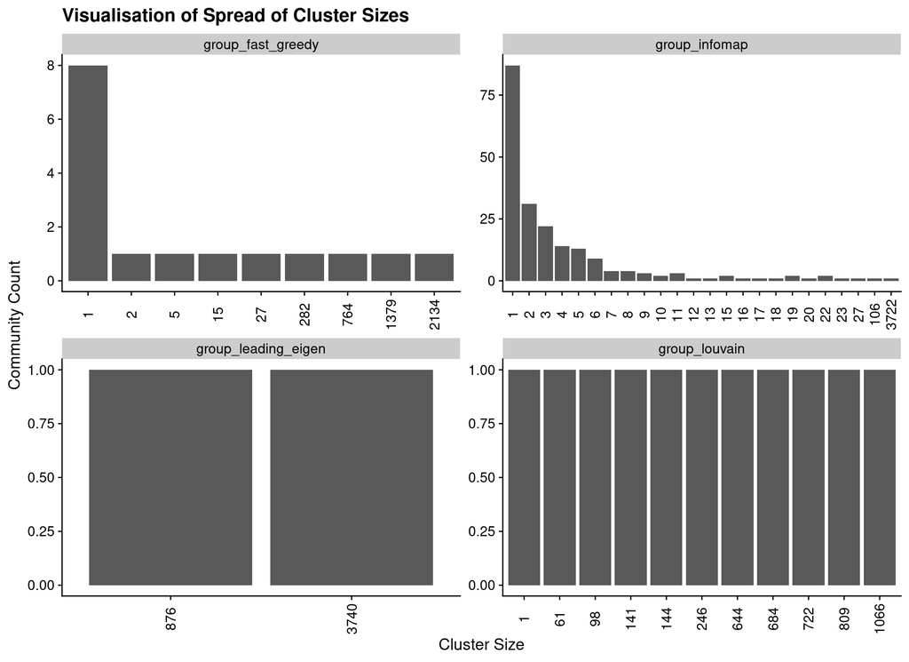

```r
plot_tbl <- cluster_data_tbl %>%
  group_by(cluster_func_name) %>%
  count(cluster_size, name = "cluster_count", sort = TRUE) %>%
  ungroup() %>%
  mutate(cluster_size = as.factor(cluster_size))


ggplot(plot_tbl) +
  geom_col(aes(x = cluster_size, y = cluster_count, group = cluster_size)) +
  facet_wrap(vars(cluster_func_name), scales = "free") +
  labs(
    x = "Cluster Size",
    y = "Community Count",
    title = "Visualisation of Spread of Cluster Sizes"
    ) +
  theme(axis.text.x = element_text(angle = 90, vjust = 0.5))
```

From this graphic, we see that we want to use `group_louvain` gives us the most even split across the data - though the sizes are still hugely unequal.

## 3.2 Create Cluster-Based Allocation

We now use this algorithm to cluster this large component in the graph, and this gives us an alternative allocation of the each `stock_code` to a product group.

```r
largecomp_clustered_tbl <- largecomp_tblgraph %>%
  mutate(
    cluster_id = group_louvain()
    ) %>%
  activate(nodes) %>%
  as_tibble() %>%
  filter(node_type == "stock") %>%
  mutate(
    cluster_group = sprintf("LOUVAIN_%03d", cluster_id)
    )

largecomp_clustered_tbl %>% glimpse()
```

```
## Rows: 4,616
## Columns: 7
## $ node_label            <chr> "85048", "79323P", "79323W", "22041", "21232", "…
## $ node_type             <chr> "stock", "stock", "stock", "stock", "stock", "st…
## $ component_id          <int> 1, 1, 1, 1, 1, 1, 1, 1, 1, 1, 1, 1, 1, 1, 1, 1, …
## $ component_size        <int> 41202, 41202, 41202, 41202, 41202, 41202, 41202,…
## $ .tidygraph_node_index <int> 1, 2, 3, 4, 5, 6, 7, 8, 9, 10, 11, 12, 13, 14, 1…
## $ cluster_id            <int> 5, 3, 3, 10, 3, 3, 7, 8, 3, 3, 3, 3, 8, 1, 1, 1,…
## $ cluster_group         <chr> "LOUVAIN_005", "LOUVAIN_003", "LOUVAIN_003", "LO…
```

# 4 Construct Non-Transaction Graphs

We now want to construct a graph where we create a link between all products that co-occur in a transaction, so that transactions are now represented by the weights on the edges of the graph, rather than being nodes.

```r
pairwise_nodes_tbl <- tnx_data_tbl %>%
  filter(
    quantity > 0,
    price > 0,
    exclude == FALSE
    ) %>%
  mutate(
    stock_code = str_to_upper(stock_code)
    ) %>%
  arrange(stock_code)

pairwise_edges_tbl <- basket_data_tbl %>%
  select(basket_data) %>%
  unnest(basket_data) %>%
  count(from = one, to = two, name = "invoice_count")


pairwise_tblgraph <- tbl_graph(
  nodes    = pairwise_nodes_tbl,
  edges    = pairwise_edges_tbl,
  directed = FALSE,
  node_key = "stock_code"
)

pairwise_tblgraph %>% print()
```

```
## # A tbl_graph: 1015088 nodes and 3424974 edges
## #
## # An undirected simple graph with 1010473 components
## #
## # Node Data: 1,015,088 × 23 (active)
##   row_id excel_sheet invoice_id stock_code description quantity invoice_date
##   <chr>  <chr>       <chr>      <chr>      <chr>          <dbl> <date>
## 1 ROW00… Year 2009-… 489437     10002      INFLATABLE…       12 2009-12-01
## 2 ROW00… Year 2009-… 490063     10002      INFLATABLE…        1 2009-12-03
## 3 ROW00… Year 2009-… 490063     10002      INFLATABLE…        1 2009-12-03
## 4 ROW00… Year 2009-… 490136     10002      INFLATABLE…        1 2009-12-03
## 5 ROW00… Year 2009-… 490140     10002      INFLATABLE…        4 2009-12-03
## 6 ROW00… Year 2009-… 490144     10002      INFLATABLE…       12 2009-12-04
## # … with 1,015,082 more rows, and 16 more variables: price <dbl>,
## #   customer_id <chr>, country <chr>, stock_code_upr <chr>, cancellation <lgl>,
## #   invoice_dttm <dttm>, invoice_month <fct>, invoice_dow <fct>,
## #   invoice_dom <chr>, invoice_hour <chr>, invoice_minute <chr>,
## #   invoice_woy <chr>, invoice_ym <chr>, stock_value <dbl>,
## #   invoice_monthprop <dbl>, exclude <lgl>
## #
## # Edge Data: 3,424,974 × 3
##    from    to invoice_count
##   <int> <int>         <int>
## 1     1   405             4
## 2     1   479             2
## 3     1   562             2
## # … with 3,424,971 more rows
```

## 4.1 Extract Largest Component

We now run clustering on the largest component of this graph.

```r
pairwise_largecomp_tblgraph <- pairwise_tblgraph %>%
  mutate(
    component_id = group_components()
    ) %>%
  group_by(component_id) %>%
  mutate(component_size = n()) %>%
  ungroup() %>%
  convert(to_subgraph, component_size == max(component_size))

pairwise_largecomp_tblgraph %>% print()
```

```
## # A tbl_graph: 4616 nodes and 3424974 edges
## #
## # An undirected simple graph with 1 component
## #
## # Node Data: 4,616 × 26 (active)
##   row_id excel_sheet invoice_id stock_code description quantity invoice_date
##   <chr>  <chr>       <chr>      <chr>      <chr>          <dbl> <date>
## 1 ROW00… Year 2009-… 489437     10002      INFLATABLE…       12 2009-12-01
## 2 ROW00… Year 2009-… 489879     10080      GROOVY CAC…        1 2009-12-02
## 3 ROW00… Year 2009-… 490017     10109      BENDY COLO…        4 2009-12-03
## 4 ROW00… Year 2009-… 489640     10120      DOGGY RUBB…       60 2009-12-01
## 5 ROW00… Year 2009-… 489597     10123C     HEARTS WRA…        3 2009-12-01
## 6 ROW00… Year 2009-… 489597     10123G     ARMY CAMO …        2 2009-12-01
## # … with 4,610 more rows, and 19 more variables: price <dbl>,
## #   customer_id <chr>, country <chr>, stock_code_upr <chr>, cancellation <lgl>,
## #   invoice_dttm <dttm>, invoice_month <fct>, invoice_dow <fct>,
## #   invoice_dom <chr>, invoice_hour <chr>, invoice_minute <chr>,
## #   invoice_woy <chr>, invoice_ym <chr>, stock_value <dbl>,
## #   invoice_monthprop <dbl>, exclude <lgl>, component_id <int>,
## #   component_size <int>, .tidygraph_node_index <int>
## #
## # Edge Data: 3,424,974 × 4
##    from    to invoice_count .tidygraph_edge_index
##   <int> <int>         <int>                 <int>
## 1     1     4             4                     1
## 2     1     5             2                     2
## 3     2     5             1                  2379
## # … with 3,424,971 more rows
```

We now run some community detection on this largest component as a way to segment the product space.

```r
pairwise_stockgroup_tbl <- pairwise_largecomp_tblgraph %>%
  mutate(
    cluster_id = group_louvain(weights = invoice_count)
    ) %>%
  activate(nodes) %>%
  as_tibble() %>%
  transmute(
    stock_code,
    cluster_label = sprintf("PAIRWISE_%03d", cluster_id)
    )

pairwise_additional_tbl <- pairwise_nodes_tbl %>%
  anti_join(pairwise_stockgroup_tbl, by = "stock_code") %>%
  transmute(
    stock_code,
    cluster_label = "PAIRWISE_OTHER"
    )

pairwise_groups_tbl <- list(
    pairwise_stockgroup_tbl,
    pairwise_additional_tbl
    ) %>%
  bind_rows() %>%
  inner_join(pairwise_nodes_tbl, by = "stock_code") %>%
  arrange(stock_code)

pairwise_groups_tbl %>% glimpse()
```

```
## Rows: 1,020,572
## Columns: 24
## $ stock_code        <chr> "10002", "10002", "10002", "10002", "10002", "10002"…
## $ cluster_label     <chr> "PAIRWISE_003", "PAIRWISE_003", "PAIRWISE_003", "PAI…
## $ row_id            <chr> "ROW0000042", "ROW0007513", "ROW0007528", "ROW000920…
## $ excel_sheet       <chr> "Year 2009-2010", "Year 2009-2010", "Year 2009-2010"…
## $ invoice_id        <chr> "489437", "490063", "490063", "490136", "490140", "4…
## $ description       <chr> "INFLATABLE POLITICAL GLOBE", "INFLATABLE POLITICAL …
## $ quantity          <dbl> 12, 1, 1, 1, 4, 12, 12, 48, 1, 48, 1, 2, 12, 1, 9, 1…
## $ invoice_date      <date> 2009-12-01, 2009-12-03, 2009-12-03, 2009-12-03, 200…
## $ price             <dbl> 0.85, 0.85, 0.85, 0.85, 0.85, 0.85, 0.85, 0.85, 0.85…
## $ customer_id       <chr> "15362", "17271", "17271", "17432", "12872", "13154"…
## $ country           <chr> "United Kingdom", "United Kingdom", "United Kingdom"…
## $ stock_code_upr    <chr> "10002", "10002", "10002", "10002", "10002", "10002"…
## $ cancellation      <lgl> FALSE, FALSE, FALSE, FALSE, FALSE, FALSE, FALSE, FAL…
## $ invoice_dttm      <dttm> 2009-12-01 09:08:00, 2009-12-03 13:49:00, 2009-12-0…
## $ invoice_month     <fct> December, December, December, December, December, De…
## $ invoice_dow       <fct> Tuesday, Thursday, Thursday, Thursday, Thursday, Fri…
## $ invoice_dom       <chr> "01", "03", "03", "03", "03", "04", "04", "04", "04"…
## $ invoice_hour      <chr> "09", "13", "13", "19", "20", "08", "12", "13", "17"…
## $ invoice_minute    <chr> "08", "49", "49", "13", "02", "46", "20", "47", "30"…
## $ invoice_woy       <chr> "49", "49", "49", "49", "49", "49", "49", "49", "49"…
## $ invoice_ym        <chr> "200912", "200912", "200912", "200912", "200912", "2…
## $ stock_value       <dbl> 10.20, 0.85, 0.85, 0.85, 3.40, 10.20, 10.20, 40.80, …
## $ invoice_monthprop <dbl> 0.04347826, 0.13043478, 0.13043478, 0.13043478, 0.13…
## $ exclude           <lgl> FALSE, FALSE, FALSE, FALSE, FALSE, FALSE, FALSE, FAL…
```